# Microplastics and human health - rapid literature review

Julian Flowers

20/01/2022

## Search

Search for `microplastics` and `human health`

```r
search <- "microplastics health human[mh] review[pt]"
n <- 153
start <- 1990
end <- 2021
key <- Sys.getenv("ncbi_key")

out <- pubmedAbstractR(search = search, n = n, start = start, end = end, ncbi_key = key)
```

```
## Please wait...Your query is (("microplastics"[MeSH Terms] OR "microplastics"[All Fields]) AND ("health"[MeSH Terms] OR "health"[All Fields]) AND "humans"[MeSH Terms]) AND review[pt] AND 1990[PDAT] : 2021[PDAT]. This returns 153 abstracts. By default 1000 abstracts are downloaded. You downloaded 1…
```

```r
out$abstracts %>%
  select(year, title, journal, pmid) %>%
  flextable::flextable(cwidth = 6)
```

| year | title | journal | pmid |
| --- | --- | --- | --- |
| 2021 | Removal of microplastics from wastewater: available techniques and way forward. | Water Sci Technol | 34928836 |
| 2021 | Investigating impact of physicochemical properties of microplastics on human health: A short bibliometric analysis and review. | Chemosphere | 34871607 |
| 2021 | UV-filter pollution: current concerns and future prospects. | Environ Monit Assess | 34822005 |
| 2021 | Key factors controlling transport of micro- and nanoplastic in porous media and its effect on coexisting pollutants. | Environ Pollut | 34785290 |
| 2021 | Impact of aquatic microplastics and nanoplastics pollution on ecological systems and sustainable remediation strategies of biodegradation and photodegradation. | Sci Total Environ | 34736954 |
| 2021 | Microplastics as a vehicle of heavy metals in aquatic environments: A review of adsorption factors, mechanisms, and biological effects. | J Environ Manage | 34700080 |
| 2021 | A review of environmental metabolism disrupting chemicals and effect biomarkers associating disease risks: Where exposomics meets metabolomics. | Environ Int | 34689039 |
| 2021 | Dynamics of airborne microplastics, appraisal and distributional behaviour in atmosphere; a review. | Sci Total Environ | 34656602 |
| 2021 | Tiered testing of micro- and nanoplastics using intestinal in vitro models to support hazard assessments. | Environ Int | 34634620 |
| 2021 | COVID-19 and antimicrobial resistance: A cross-study. | Sci Total Environ | 34634340 |
| 2021 | Effects of micro(nano)plastics on higher plants and the rhizosphere environment. | Sci Total Environ | 34627902 |
| 2021 | Microplastics in the Food Chain: Food Safety and Environmental Aspects. | Rev Environ Contam Toxicol | 34611754 |
| 2021 | Potential microplastics impacts on African fishing resources. | Sci Total Environ | 34599958 |
| 2021 | Microplastics: A review of analytical methods, occurrence and characteristics in food, and potential toxicities to biota. | Sci Total Environ | 34571218 |
| 2021 | Photoluminescence-Based Techniques for the Detection of Micro- and Nanoplastics. | Chemistry | 34519368 |
| 2021 | Microplastics in aquatic environment: Challenges and perspectives. | Chemosphere | 34470176 |
| 2021 | Risks of Covid-19 face masks to wildlife: Present and future research needs. | Sci Total Environ | 34465061 |
| 2021 | Plastic Impacts in Argentina: a Critical Research Review Contributing to the Global Knowledge. | Curr Environ Health Rep | 34458967 |
| 2021 | Science-society-policy interface for microplastic and nanoplastic: Environmental and biomedical aspects. | Environ Pollut | 34454195 |
| 2021 | Challenges and opportunities in bioremediation of micro-nano plastics: A review. | Sci Total Environ | 34454140 |
| 2021 | A critical synthesis of current peer-reviewed literature on the environmental and human health impacts of COVID-19 PPE litter: New findings and next steps. | J Hazard Mater | 34449351 |
| 2021 | Overview on the occurrence of microplastics in air and implications from the use of face masks during the COVID-19 pandemic. | Sci Total Environ | 34426330 |
| 2021 | Microplastic pollution in freshwater systems in Southeast Asia: contamination levels, sources, and ecological impacts. | Environ Sci Pollut Res Int | 34386926 |
| 2021 | On the way to reduce marine microplastics pollution. Research landscape of psychosocial drivers. | Sci Total Environ | 34358749 |
| 2021 | Biodegradation of microplastics: Better late than never. | Chemosphere | 34351281 |
| 2021 | Toxicity of nanoplastics for zebrafish embryos, what we know and where to go next. | Sci Total Environ | 34346375 |
| 2021 | Extraction and detection methods of microplastics in food and marine systems: A critical review. | Chemosphere | 34346338 |
| 2021 | Influence of Microplastics on the Mobility, Bioavailability, and Toxicity of Heavy Metals: A Review. | Bull Environ Contam Toxicol | 34331555 |
| 2021 | Environmental occurrence, fate, impact, and potential solution of tire microplastics: Similarities and differences with tire wear particles. | Sci Total Environ | 34328941 |
| 2021 | Microplastic contaminants in the aqueous environment, fate, toxicity consequences, and remediation strategies. | Environ Res | 34310963 |

[output cut: 123 more lines]

### Abstract themes

#### Clustering

```r
corpus <- out$abstracts %>%
  rename(absText = abstract) %>%
  create_abstract_corpus()

corpus <- corpus$corpus %>%
  filter(!word %in% c("human", "health"))


cluster <- create_abstract_cluster(corpus, minPts = 4)
```

```
## If there are a small number of abstracts, set perplexity value
## to less than 30% of abstract count
```

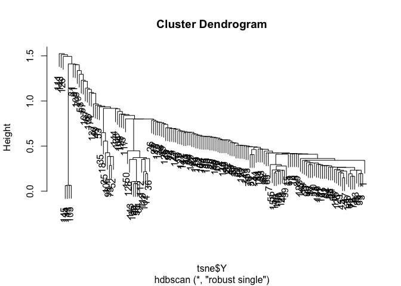

```
## 0.402 sec elapsed
```

```r
cluster$cluster_count
```

```
## [1] 6
```

```r
labels <- create_cluster_labels(corpus, clustering = cluster$clustering)

unique(labels$labels)
```

```
## # A tibble: 6 × 2
## # Groups:   cluster [6]
##   cluster clus_names
##     <dbl> <chr>
## 1       0 pollut-environ-effect-studi-microplast-review
## 2       1 mnp-micro-challeng-environ-review
## 3       2 gut-microbiota-chemic-exposur-pollut-effect-microplast-review
## 4       3 np-mp-nanoplast-environment-plastic-effect-review-microplast
## 5       4 np-mp-nanoplast-degrad-micro-toxic-exposur-effect-studi-plastic-poten…
## 6       5 research-environ-potenti-effect-microplast-review
```

#### Topic modelling

```r
corp <- quanteda::corpus(out$abstract$abstract)
dtm <- dfm(corp, remove = c(stopwords("en"), "human", "health"),  remove_punct = TRUE)


stm_c <- convert(dtm, to = "stm")

topics <- stm(documents = stm_c$documents, vocab = stm_c$vocab, data = stm_c$meta, K = 10, init.type = "Spectral")
```

[output not shown]

[output cut: 106 more lines]

[output not shown]

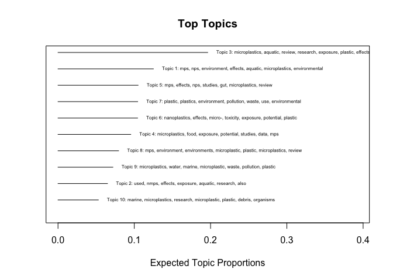

```r
plot(topics, n = 7, text.cex = .5)
```

### Sample article

Assessment of Human Health Risks Posed by Nano-and Microplastics Is Currently Not Feasible.

```r
details <- europepmc::epmc_details(33261100)
d1 <- europepmc::epmc_details(33264963)

d1$basic
```

```
## # A tibble: 1 × 35
##   id       source pmid   doi    title authorString pubYear pageInfo abstractText
##   <chr>    <chr>  <chr>  <chr>  <chr> <chr>        <chr>   <chr>    <chr>
## 1 33264963 MED    33264… 10.10… Envi… Rai PK, Lee… 2021    123910   In recent d…
## # … with 26 more variables: affiliation <chr>, publicationStatus <chr>,
## #   language <chr>, pubModel <chr>, isOpenAccess <chr>, inEPMC <chr>,
## #   inPMC <chr>, hasPDF <chr>, hasBook <chr>, hasSuppl <chr>,
## #   citedByCount <int>, hasData <chr>, hasReferences <chr>,
## #   hasTextMinedTerms <chr>, hasDbCrossReferences <chr>, hasLabsLinks <chr>,
## #   authMan <chr>, epmcAuthMan <chr>, nihAuthMan <chr>,
## #   hasTMAccessionNumbers <chr>, dateOfCompletion <chr>, …
```

```r
ft_xml <- tidypmc::pmc_xml(details$basic$pmcid)
ft <- tidypmc::pmc_text(ft_xml)
ft_tables <- tidypmc::pmc_table(ft_xml)
ft_refs <- tidypmc::pmc_reference(ft_xml)

summary <- ft |>
  filter(section == "6. Concluding Remarks") %>%
  select(section, text) %>%
  mutate(text = paste(text, collapse = "\\.")) %>%
  distinct() %>%
  mutate(summ = map(text, ~myScrapers::text_summariser(.x, n = 4))) %>%
  unnest("summ")
```

### tl;dr

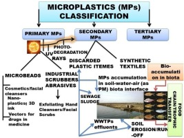

*Classification of microplastics. From* Rai et al. (2021)

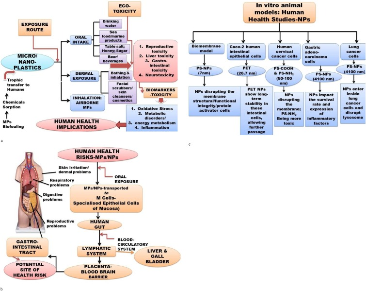

*Potential human health impacts of mps. From* Rai et al. (2021)

The facts that global plastics production has been growing exponentially since the 1950s, and that nearly the entire human population is nowadays permanently exposed to plastic-derived nmps, warrant a critical view of possible health risks posed by nmps, likely not arising from acute toxicity but maybe from long-term accumulation in the human body, or indirect effects caused by alterations in the gut microbiome. In past years the topic “microplastics pollution and possible health risks for humans” raised much attention in the public, and led to political discussions to limit or ban the industrial use of plastic microparticles in various products, although scientific data proving or disproving acute or long-term toxicity of nmps are scarce. Effects on human health remain elusive. Owing to the fact that it is extremely difficult to isolate and (chemically) identify micro- and, in particular, nanoparticles from environmental and biological samples, precise numbers about the human exposure towards nmps via the supposedly main uptake routes of ingestion and inhalation have not been determined yet.

### References

Rai, Prabhat Kumar, Jechan Lee, Richard J. C. Brown, and Ki-Hyun Kim. 2021. “Environmental Fate, Ecotoxicity Biomarkers, and Potential Health Effects of Micro- and Nano-Scale Plastic Contamination.” *Journal of Hazardous Materials* 403 (February): 123910. https://doi.org/10.1016/j.jhazmat.2020.123910.